# Chapter 15 Hmsc analysis

**Note:** Load all required data objects including genome counts, metadata, GIFT database, and color schemes. Read GIFT color mapping file to create legend labels for functional groups.

```r
load("data/data.Rdata")

gift_colors <- read_tsv("data/gift_colors.tsv") %>%
  mutate(legend=str_c(Code_function," - ",Function))
```

**Note:** Set HMSC model parameters for MCMC sampling: number of samples, thinning interval, transient (burn-in) period, and posterior support thresholds for determining significant associations.

```r
#Parameters
nSamples=250
thin=1000
transient=nSamples * thin
support_threshold=0.9
negsupport_threshold=1-support_threshold
```

**Note:** Load the unfitted HMSC model object and import the fitted model posterior samples from HPC. The fitted model is downloaded from a remote server, then posterior samples are imported and processed according to the specified sampling parameters.

```r
#Load unfitted
load(file = "hmsc/model_env_ani")

#Load fitted (as a temporary file)
tmp <- tempfile(fileext = ".rds")
options(timeout = max(600, getOption("timeout")))
download.file("https://sid.erda.dk/share_redirect/Gh0WbM42c4/Hmsc_model_env_ani.rds", tmp, mode = "wb")
importFromHPC = readRDS(tmp)[[1]]
unlink(tmp)

postList = importFromHPC[1:4]
fit_model_16 = importPosteriorFromHPC(m, postList, nSamples, thin, transient)
```

**Note:** Compute variance partitioning to quantify the proportion of variance explained by each environmental variable and random effect (animal, site) for each genome. Calculate predicted values and evaluate model fit using R², displaying the distribution of R² values across genomes.

```r
# Compute variance partitioning
varpart=computeVariancePartitioning(fit_model_16)

varpart$vals %>%
   as.data.frame() %>%
   rownames_to_column(var="variable") %>%
   pivot_longer(!variable, names_to = "genome", values_to = "value") %>%
   mutate(variable=factor(variable)) %>%
   group_by(variable) %>%
   summarise(mean=mean(value)*100,sd=sd(value)*100) %>%
   tt()
```

| variable | mean | sd |
| --- | --- | --- |
| density | 4.4521451 | 3.7862996 |
| development | 2.6633417 | 1.9906652 |
| devil | 2.1603302 | 2.1055054 |
| diversity | 2.4635272 | 2.3605516 |
| logseqdepth | 6.9467598 | 4.7664193 |
| precipitation | 5.5090724 | 4.9044390 |
| Random: animal | 49.2241965 | 16.2548368 |
| Random: site | 19.7924978 | 13.8819778 |
| sex | 0.9729754 | 0.8693063 |
| temperature | 2.5660841 | 2.6909419 |
| weight | 3.2490698 | 2.5720832 |

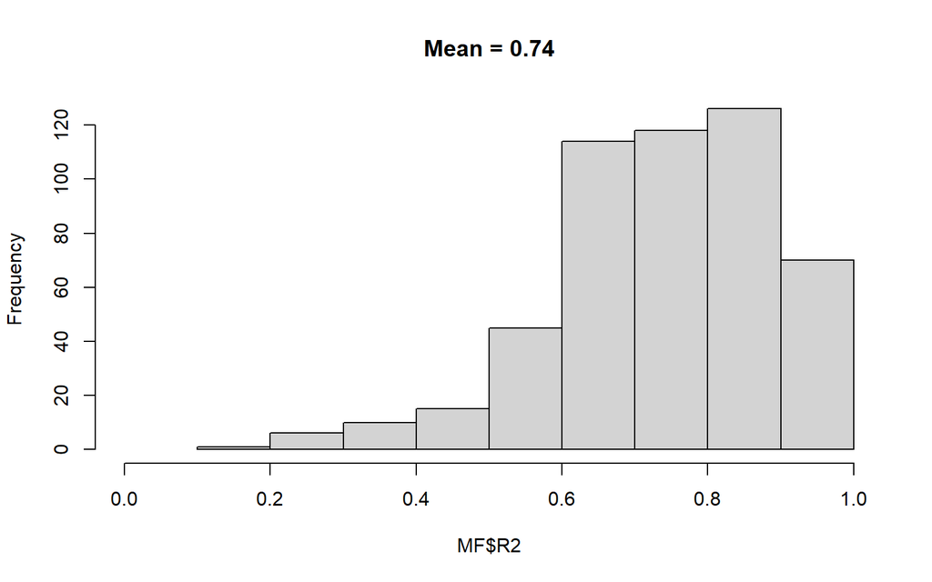

```r
preds = computePredictedValues(fit_model_16)
MF = evaluateModelFit(hM=fit_model_16, predY=preds)
hist(MF$R2, xlim = c(0,1), main=paste0("Mean = ", round(mean(MF$R2),2)))
```

**Note:** Create a phylogenetic tree visualization with variance partitioning results displayed as stacked bars next to each tip. The tree shows phylum annotations and variance contributions from each predictor variable, allowing visualization of how environmental and random effects vary across the phylogenetic tree.

```r
# 1) Build the phylogeny in the same species set/order as varpart
vp_tree_phylo <- genome_tree %>%
  keep.tip(tip = colnames(varpart$vals)) %>%
  force.ultrametric(method = "extend")

vp_tree <- ggtree(vp_tree_phylo, size = 0.3)

# 2) Phylum annotation in tree tip order
phylums_vp <- genome_metadata %>%
  filter(genome %in% vp_tree$data$label) %>%
  arrange(match(genome, vp_tree$data$label)) %>%
  mutate(phylum = factor(phylum, levels = unique(phylum))) %>%
  column_to_rownames("genome") %>%
  select(phylum)

vp_tree <- gheatmap(
  vp_tree,
  phylums_vp,
  offset    = -0.2,
  width     = 0.1,
  colnames  = FALSE
) +
  scale_fill_manual(values = phylum_colors) +
  labs(fill = "Phylum")

# start a new fill scale for the variance bars
vp_tree <- vp_tree + new_scale_fill()

# 3) Long variance-partitioning table
varpart_long <- varpart$vals %>%
  as.data.frame() %>%
  rownames_to_column("variable") %>%
  pivot_longer(
    cols      = -variable,
    names_to  = "label",   # must be 'label' to match tree tip labels
    values_to = "value"
  ) %>%
  mutate(
    # reorder predictors in a sensible way for the legend
    variable = factor(
      variable,
      levels = rev(c(
        "devil", "temperature", "density",
        "development", "weight",
        "precipitation", "diversity",
        "logseqdepth",
        "Random: animal", "Random: site"
      ))
    )
  )

# 4) Add stacked bars with geom_fruit
vp_tree +
  geom_fruit(
    data   = varpart_long,
    geom   = geom_bar,
    mapping = aes(
      x    = value,
      y    = label,
      fill = variable
    ),
    stat        = "identity",
    orientation = "y",
    pwidth      = 2,
    offset      = 0.05
  ) +
  labs(fill = "Variable")
```

[output not shown]

## 15.1 Phylogenetic signal

**Note:** Assess phylogenetic signal in the model by extracting the Rho parameter from the posterior distribution. Rho quantifies the strength of phylogenetic correlation in species responses, with values near 1 indicating strong phylogenetic signal and values near 0 indicating weak signal. Calculate credible intervals and visualize the posterior distribution.

```r
# Convert to coda object to inspect Rho (phylogenetic signal)
mpost <- convertToCodaObject(fit_model_16)

# Overall Rho posterior (phylogenetic signal on the species random effect)
rho_vec <- unlist(mpost$Rho)

# 90% credible interval and median
rho_summary <- quantile(rho_vec, probs = c(0.05, 0.5, 0.95))
rho_summary

# Optional: density plot for the appendix
plot(density(rho_vec),
     main = "Posterior of phylogenetic signal (Rho)",
     xlab = "Rho")
abline(v = rho_summary[2], col = "red", lty = 2)
```

[output not shown]

**Note:** Extract posterior support values for all predictor variables and create a heatmap visualization on a phylogenetic tree. The heatmap shows whether each genome has a positive, negative, or neutral association with each environmental variable based on posterior support thresholds. Phylum annotations are displayed alongside the tree tips.

```r
hmsc_tree <- genome_tree %>%
        keep.tip(., tip=m$spNames)

# Posterior estimates
post_estimates <- getPostEstimate(hM=fit_model_16, parName="Beta")$support %>%
    as.data.frame() %>%
    mutate(variable=m$covNames) %>%
    pivot_longer(!variable, names_to = "genome", values_to = "value") %>%
    mutate(trend = case_when(
          value >= support_threshold ~ "Positive",
          value <= negsupport_threshold ~ "Negative",
          TRUE ~ "Neutral"))

post_table <- post_estimates %>%
    mutate(genome=factor(genome, levels=rev(hmsc_tree$tip.label))) %>%
    select(-trend) %>%
    mutate(value = case_when(
          value >= support_threshold ~ "Positive",
          value <= negsupport_threshold ~ "Negative",
          TRUE ~ "Neutral")) %>%
    mutate(value=factor(value, levels=c("Positive","Neutral","Negative"))) %>%
    pivot_wider(names_from = variable, values_from = value) %>%
    rename(intercept=2) %>%
   column_to_rownames(var="genome") %>%
  select(-intercept)

# Basal ggtree
postestimates_tree <- hmsc_tree %>%
        force.ultrametric(.,method="extend") %>%
        ggtree(., size = 0.3)


# Phylums
phylums <- genome_metadata %>%
    filter(genome %in% hmsc_tree$tip.label) %>%
    arrange(match(genome, hmsc_tree$tip.label)) %>%
    mutate(phylum = factor(phylum, levels = unique(phylum))) %>%
    column_to_rownames(var = "genome") %>%
    select(phylum)


#Add phylum colors next to the tree tips
postestimates_tree <- gheatmap(postestimates_tree, phylums, offset=-0.2, width=0.1, colnames=FALSE) +
      scale_fill_manual(values=phylum_colors)+
      labs(fill="Phylum")

#Reset fill scale to use a different colour profile in the heatmap
postestimates_tree <- postestimates_tree + new_scale_fill()

# Add posterior significant heatmap

postestimates_tree <- gheatmap(postestimates_tree, post_table, offset=0, width=0.5, colnames=TRUE, colnames_position="top",colnames_angle=90, colnames_offset_y=1, hjust=0) +
        scale_fill_manual(values=c("#be3e2b","#f4f4f4","#b2b530"))+
        labs(fill="Trend")

postestimates_tree +
        vexpand(.30, 1)  # expand top
```

[output not shown]

**Note:** Examine the congruence between devil and temperature associations at the taxonomic level. Create contingency tables showing how many genomes have each combination of devil and temperature responses (positive, negative, neutral). Visualize taxonomic patterns by phylum to identify whether certain taxonomic groups show consistent response patterns.

```r
# Long table of trends for devil and temperature per genome
devil_temp_trends <- post_table %>%
  rownames_to_column("genome") %>%
  select(genome, devil, temperature) %>%
  left_join(genome_metadata, by = "genome")

# Overall contingency of trends
devil_temp_tab <- devil_temp_trends %>%
  count(devil, temperature) %>%
  arrange(desc(n))

devil_temp_tab %>% tt()
```

| devil | temperature | n |
| --- | --- | --- |
| Positive | Neutral | 258 |
| Positive | Positive | 104 |
| Neutral | Neutral | 98 |
| Positive | Negative | 44 |
| Negative | Neutral | 26 |
| Neutral | Negative | 24 |
| Negative | Positive | 9 |
| Neutral | Positive | 8 |
| Negative | Negative | 5 |

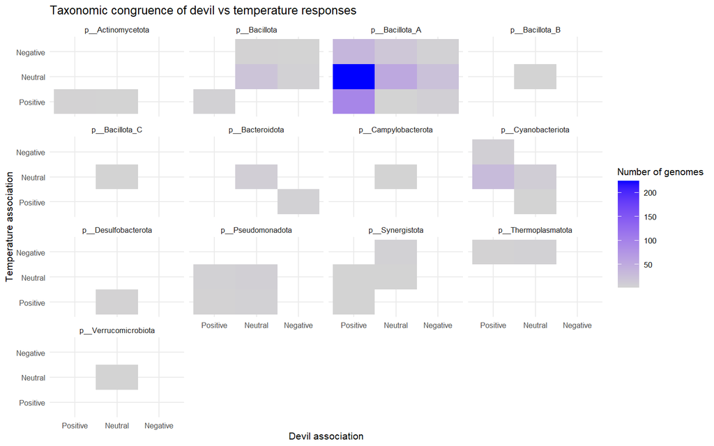

```r
# Phylum-level congruence: how many genomes in each combo
devil_temp_phylum <- devil_temp_trends %>%
  group_by(phylum, devil, temperature) %>%
  summarise(n = n(), .groups = "drop")

# Keep only non-zero combos (for cleaner plots)
devil_temp_phylum %>%
  filter(n > 0) %>%
  ggplot(aes(x = devil, y = temperature, fill = n)) +
  geom_tile() +
  facet_wrap(~ phylum) +
  scale_fill_gradient(low = "lightgrey", high = "blue") +
  labs(
    x = "Devil association",
    y = "Temperature association",
    fill = "Number of genomes",
    title = "Taxonomic congruence of devil vs temperature responses"
  ) +
  theme_minimal(base_size = 8)
```

**Note:** Map GIFT functional annotations (bundle-level) to element-level for genomes included in the HMSC model. Join functional trait data with posterior support trends to enable analysis of functional differences between genomes with different environmental associations.

```r
elements_response <- genome_gifts[rownames(post_table),colnames(genome_gifts) %in% GIFT_db$Code_bundle] %>%
  to.elements(.,GIFT_db=GIFT_db) %>%
  as.data.frame() %>%
  rownames_to_column(var="genome") %>%
  pivot_longer(!genome,names_to="GIFT", values_to="value") %>%
  left_join(post_table %>% rownames_to_column(var = "genome"), by="genome")
```

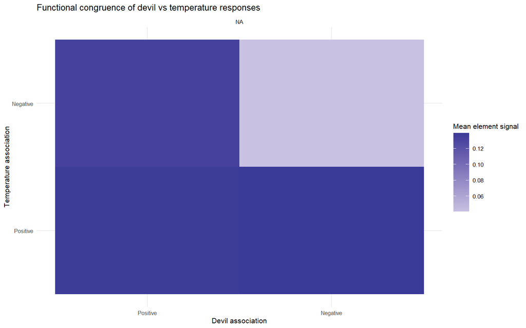

```r
# elements_response has: genome, GIFT, value, and trend columns (devil, temperature, ...)
# Focus on non-neutral responses for both variables
elem_dev_temp <- elements_response %>%
  filter(devil != "Neutral",
         temperature != "Neutral") %>%
  mutate(
    devil      = droplevels(devil),
    temperature = droplevels(temperature)
  )

# Summarise at the element level: mean value per devil/temperature combo
func_congruence_elem <- elem_dev_temp %>%
  group_by(GIFT, devil, temperature) %>%
  summarise(
    mean_val = mean(value, na.rm = TRUE),
    n        = n(),
    .groups  = "drop"
  )

# Collapse to functional group (Code_function)
func_congruence_group <- func_congruence_elem %>%
  left_join(GIFT_db, by = c("GIFT" = "Code_bundle")) %>%
  group_by(Code_function, devil, temperature) %>%
  summarise(
    mean_val = mean(mean_val, na.rm = TRUE),
    .groups  = "drop"
  )

# For readability, keep only functional groups that show some variation
interesting_funcs <- func_congruence_group %>%
  group_by(Code_function) %>%
  summarise(range_val = max(mean_val) - min(mean_val), .groups = "drop") %>%
  slice_max(order_by = range_val, n = 12) %>%
  pull(Code_function)

func_congruence_group %>%
  filter(Code_function %in% interesting_funcs) %>%
  ggplot(aes(x = devil, y = temperature, fill = mean_val)) +
  geom_tile() +
  facet_wrap(~ Code_function) +
  scale_fill_gradient2() +
  labs(
    x = "Devil association",
    y = "Temperature association",
    fill = "Mean element signal",
    title = "Functional congruence of devil vs temperature responses"
  ) +
  theme_minimal(base_size = 8)
```

## 15.2 Association with devil

**Note:** Summarize devil associations across taxonomic levels. Count and calculate percentages of genomes with positive and negative devil associations at phylum, order, family, and genus levels. This helps identify which taxonomic groups show the strongest associations with devil presence.

```r
post_table$devil %>% table()
```

```
## .
## Positive  Neutral Negative
##      406      130       40
```

```r
devil_phylum_perc <- post_table %>%
  rownames_to_column(var = "genome") %>%
  left_join(genome_metadata, by = "genome") %>%
  group_by(phylum) %>%
  summarise(positive = sum(devil == "Positive"),
            percent_positive = mean(devil == "Positive") * 100,
            negative = sum(devil == "Negative"),
            percent_negative = mean(devil == "Negative") * 100)

devil_phylum_perc %>%
  arrange(-percent_positive)
```

```
## # A tibble: 13 × 5
##    phylum               positive percent_positive negative percent_negative
##    <chr>                   <int>            <dbl>    <int>            <dbl>
##  1 p__Cyanobacteriota         36             80          0             0
##  2 p__Bacillota_A            355             77.7       33             7.22
##  3 p__Actinomycetota           2             66.7        0             0
##  4 p__Pseudomonadota           5             35.7        0             0
##  5 p__Synergistota             2             33.3        0             0
##  6 p__Thermoplasmatota         2             33.3        0             0
##  7 p__Bacillota                4             13.8        4            13.8
##  8 p__Bacillota_B              0              0          0             0
##  9 p__Bacillota_C              0              0          0             0
## 10 p__Bacteroidota             0              0          3            30
## 11 p__Campylobacterota         0              0          0             0
## 12 p__Desulfobacterota         0              0          0             0
## 13 p__Verrucomicrobiota        0              0          0             0
```

```r
devil_phylum_perc %>%
  arrange(-percent_negative)
```

```
## # A tibble: 13 × 5
##    phylum               positive percent_positive negative percent_negative
##    <chr>                   <int>            <dbl>    <int>            <dbl>
##  1 p__Bacteroidota             0              0          3            30
##  2 p__Bacillota                4             13.8        4            13.8
##  3 p__Bacillota_A            355             77.7       33             7.22
##  4 p__Actinomycetota           2             66.7        0             0
##  5 p__Bacillota_B              0              0          0             0
##  6 p__Bacillota_C              0              0          0             0
##  7 p__Campylobacterota         0              0          0             0
##  8 p__Cyanobacteriota         36             80          0             0
##  9 p__Desulfobacterota         0              0          0             0
## 10 p__Pseudomonadota           5             35.7        0             0
## 11 p__Synergistota             2             33.3        0             0
## 12 p__Thermoplasmatota         2             33.3        0             0
## 13 p__Verrucomicrobiota        0              0          0             0
```

```r
# Sub-phylum level

post_table %>%
  rownames_to_column(var = "genome") %>%
  left_join(genome_metadata, by = "genome") %>%
  filter(phylum=="p__Bacillota_A") %>%
  group_by(order) %>%
  summarise(positive = sum(devil == "Positive"),
            percent_positive = mean(devil == "Positive") * 100,
            negative = sum(devil == "Negative"),
            percent_negative = mean(devil == "Negative") * 100) %>%
  arrange(-percent_positive)
```

```
## # A tibble: 8 × 5
##   order                   positive percent_positive negative percent_negative
##   <chr>                      <int>            <dbl>    <int>            <dbl>
## 1 o__Monoglobales                3            100          0             0
## 2 o__Peptostreptococcales        1            100          0             0
## 3 o__UMGS1883                    6            100          0             0
## 4 o__Lachnospirales            165             89.7        8             4.35
## 5 o__Oscillospirales           107             85.6        0             0
## 6 o__Christensenellales         69             85.2        0             0
## 7 o__UBA1381                     4             40          0             0
## 8 o__TANB77                      0              0         25            53.2
```

```r
post_table %>%
  rownames_to_column(var = "genome") %>%
  left_join(genome_metadata, by = "genome") %>%
  filter(order=="o__TANB77") %>%
  group_by(family) %>%
  summarise(positive = sum(devil == "Positive"),
            percent_positive = mean(devil == "Positive") * 100,
            negative = sum(devil == "Negative"),
            percent_negative = mean(devil == "Negative") * 100) %>%
  arrange(-percent_positive)
```

```
## # A tibble: 2 × 5
##   family     positive percent_positive negative percent_negative
##   <chr>         <int>            <dbl>    <int>            <dbl>
## 1 f__CAG-465        0                0        6            100
## 2 f__CAG-508        0                0       19             46.3
```

```r
post_table %>%
  rownames_to_column(var = "genome") %>%
  left_join(genome_metadata, by = "genome") %>%
  filter(family=="f__CAG-508") %>%
  group_by(genus) %>%
  summarise(positive = sum(devil == "Positive"),
            percent_positive = mean(devil == "Positive") * 100,
            negative = sum(devil == "Negative"),
            percent_negative = mean(devil == "Negative") * 100) %>%
  arrange(-percent_positive)
```

```
## # A tibble: 9 × 5
##   genus          positive percent_positive negative percent_negative
##   <chr>             <int>            <dbl>    <int>            <dbl>
## 1 g__                   0                0        0              0
## 2 g__CAG-269            0                0       10             83.3
## 3 g__CAG-273            0                0        0              0
## 4 g__CAG-492            0                0        1             50
## 5 g__CAG-793            0                0        0              0
## 6 g__CAKPSH01           0                0        1            100
## 7 g__JAAWPK01           0                0        2             66.7
## 8 g__Scatovivens        0                0        4             28.6
## 9 g__UMGS1994           0                0        1             25
```

**Note:** Extract posterior mean and support values for the devil coefficient (β) for each genome. Create a scatter plot showing the relationship between the mean β coefficient and posterior support, colored by phylum. This visualization helps identify genomes with strong, well-supported associations with devil presence.

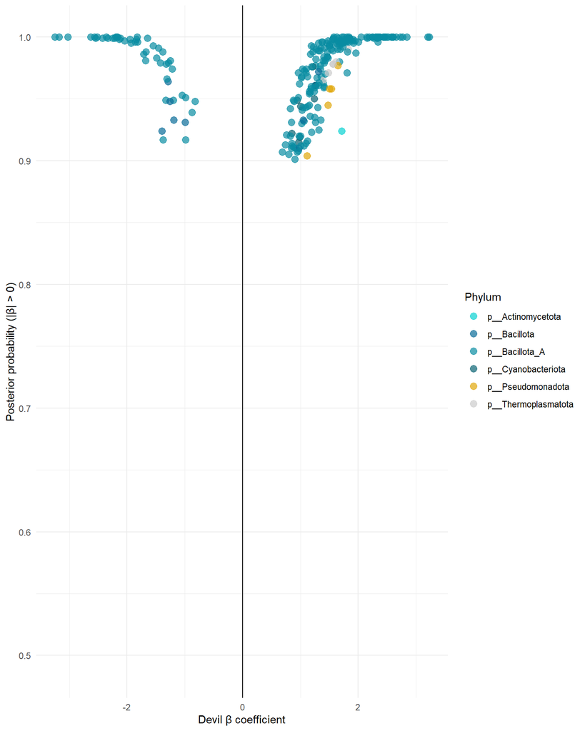

```r
# Mean beta for 'devil' per genome
devil_estimate <- getPostEstimate(hM = fit_model_16, parName = "Beta")$mean %>%
  as.data.frame() %>%
  mutate(variable = m$covNames) %>%
  filter(variable == "devil") %>%
  pivot_longer(!variable, names_to = "genome", values_to = "mean") %>%
  dplyr::select(genome, mean)

# Posterior support for 'devil' per genome
devil_support <- getPostEstimate(hM = fit_model_16, parName = "Beta")$support %>%
  as.data.frame() %>%
  mutate(variable = m$covNames) %>%
  filter(variable == "devil") %>%
  pivot_longer(!variable, names_to = "genome", values_to = "support") %>%
  dplyr::select(genome, support)

devil_beta <- inner_join(devil_estimate, devil_support, by = "genome") %>%
  left_join(genome_metadata, by = "genome")

devil_beta %>%
  mutate(
    significant   = support >= support_threshold | support <= negsupport_threshold,
    support_plot  = ifelse(mean < 0, 1 - support, support), # support for the sign of beta
    phylum_sig    = ifelse(significant & support_plot > 0.9, phylum, NA)
  ) %>%
  ggplot(aes(x = mean, y = support_plot, colour = phylum_sig)) +
  geom_point(alpha = 0.7, size = 3) +
  scale_color_manual(values = phylum_colors, na.translate = FALSE) +
  geom_vline(xintercept = 0) +
  labs(
    x = "Devil β coefficient",
    y = "Posterior probability (|β| > 0)",
    colour = "Phylum"
  ) +
  theme_minimal()
```

**Note:** Calculate 80% credible intervals (10th and 90th percentiles) for the devil β coefficient for each genome. Filter to genomes with credible non-zero effects (where the credible interval does not include zero) and visualize these with error bars, ordered by mean β value.

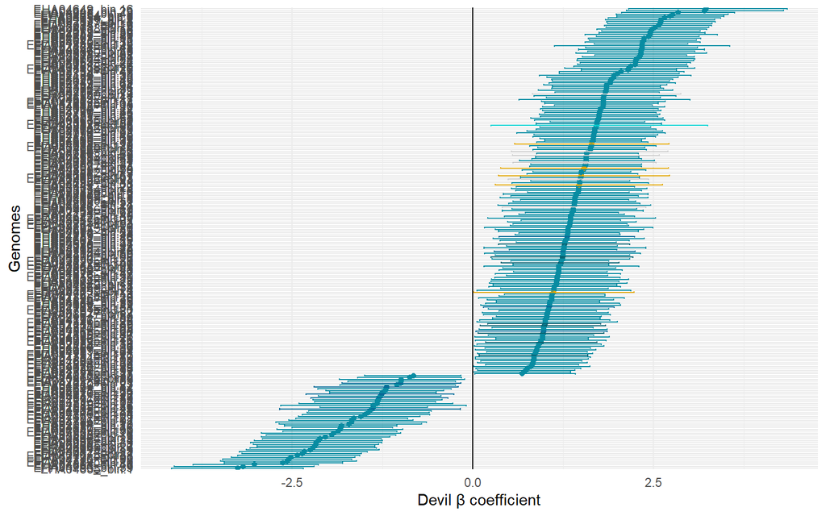

```r
# Credible intervals for 'devil'
devil_q <- getPostEstimate(hM = fit_model_16,
                           parName = "Beta",
                           q = c(0.1, 0.9))$q

idx_devil <- which(m$covNames == "devil")
n_genomes <- length(m$spNames)

devil_ci <- map_dfr(1:n_genomes, ~ {
  tibble(
    genome = m$spNames[.x],
    q10 = devil_q[1, idx_devil, .x],
    q90 = devil_q[2, idx_devil, .x]
  )
}) %>%
  right_join(devil_estimate, by = "genome") %>%
  left_join(genome_metadata, by = "genome")

# Genomes with credible non-zero devil effect
devil_ci %>%
  filter(q10 > 0 | q90 < 0) %>%
  ggplot(aes(x = mean,
             y = forcats::fct_reorder(genome, mean),
             xmin = q10, xmax = q90,
             colour = phylum)) +
  geom_point() +
  geom_errorbar() +
  geom_vline(xintercept = 0) +
  scale_color_manual(values = phylum_colors) +
  theme_minimal() +
  labs(x = "Devil β coefficient",
       y = "Genomes") +
  theme(legend.position = "none")
```

**Note:** Identify and visualize the top 30 genomes with the strongest positive and top 30 with the strongest negative credible devil associations. Create a forest plot showing these top genomes with their credible intervals, ordered by mean β coefficient and colored by phylum.

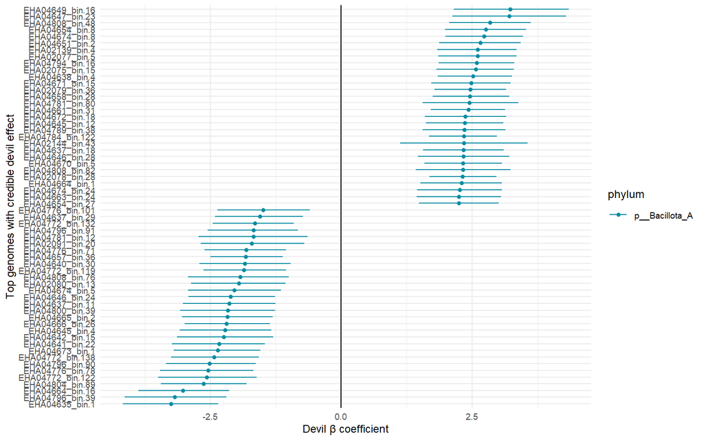

```r
# Keep only genomes with credible non-zero effect
devil_ci_sig <- devil_ci %>%
  filter(q10 > 0 | q90 < 0)

# 4. Take top N positive and top N negative genomes
N_top <- 30

devil_ci_top <- devil_ci_sig %>%
  slice_max(order_by = mean, n = N_top, with_ties = FALSE) %>%
  bind_rows(
    devil_ci_sig %>%
      slice_min(order_by = mean, n = N_top, with_ties = FALSE)
  ) %>%
  distinct(genome, .keep_all = TRUE)

# 5. Plot
devil_ci_top %>%
  ggplot(aes(x = mean,
             y = forcats::fct_reorder(genome, mean),
             xmin = q10, xmax = q90,
             colour = phylum)) +
  geom_point() +
  geom_errorbar(width = 0) +
  geom_vline(xintercept = 0) +
  scale_color_manual(values = phylum_colors) +
  theme_minimal(base_size = 9) +
  labs(
    x = "Devil β coefficient",
    y = "Top genomes with credible devil effect"
  ) +
  theme(legend.position = "right")
```

**Note:** Summarize devil β coefficients at the phylum level by calculating mean β and 80% credible intervals (10th and 90th percentiles) for each phylum. Visualize phylum-level associations with error bars to show the overall pattern of devil associations across major taxonomic groups.

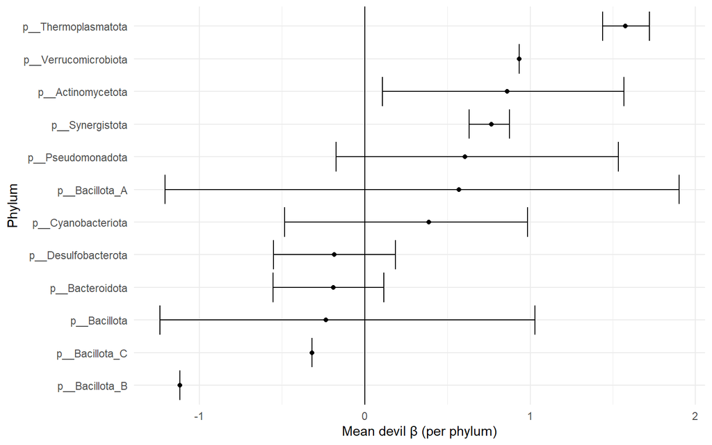

```r
devil_phylum_ci <- devil_ci %>%
  group_by(phylum) %>%
  summarise(
    mean_beta = mean(mean),
    q10 = quantile(mean, 0.1),
    q90 = quantile(mean, 0.9),
    .groups = "drop"
  )

devil_phylum_ci %>%
  ggplot(aes(x = mean_beta,
             y = forcats::fct_reorder(phylum, mean_beta),
             xmin = q10, xmax = q90)) +
  geom_point() +
  geom_errorbar() +
  geom_vline(xintercept = 0) +
  theme_minimal() +
  labs(x = "Mean devil β (per phylum)",
       y = "Phylum")
```

**Note:** Create summary tables of genomes with credible positive and negative devil associations. Filter genomes where the 80% credible interval excludes zero, then extract taxonomic information and β statistics. Display these as formatted tables showing the genomes with the strongest associations.

```r
devil_positive <- devil_ci %>%
  filter(q10 > 0) %>%
  arrange(-mean) %>%
  dplyr::select(genome, phylum, class, order, family, genus, species, mean, q10, q90)

devil_negative <- devil_ci %>%
  filter(q90 < 0) %>%
  arrange(mean) %>%
  dplyr::select(genome, phylum, class, order, family, genus, species, mean, q10, q90)

devil_positive %>% tt()  # tinytable
```

| genome | phylum | class | order | family | genus | species | mean | q10 | q90 |
| --- | --- | --- | --- | --- | --- | --- | --- | --- | --- |
| EHA04649_bin.16 | p__Bacillota_A | c__Clostridia | o__Oscillospirales | f__CAG-272 | g__DTU064 | s__DTU064 sp021202555 | 3.2273248 | 2.1521971616 | 4.347236 |
| EHA04647_bin.23 | p__Bacillota_A | c__Clostridia | o__Oscillospirales | f__CAG-272 | g__DTU064 | s__DTU064 sp021202555 | 3.2058860 | 2.1247540312 | 4.296003 |
| EHA04808_bin.48 | p__Bacillota_A | c__Clostridia | o__Oscillospirales | f__Oscillospiraceae | g__JAJQCF01 | s__JAJQCF01 sp021202845 | 2.8386635 | 2.0619497710 | 3.618585 |
| EHA04654_bin.8 | p__Bacillota_A | c__Clostridia | o__Oscillospirales | f__Oscillospiraceae | g__JAJQCF01 | s__JAJQCF01 sp021202845 | 2.7665514 | 1.9827593029 | 3.534520 |
| EHA04674_bin.8 | p__Bacillota_A | c__Clostridia | o__Oscillospirales | f__Oscillospiraceae | g__JAJQCF01 | s__JAJQCF01 sp021202845 | 2.7272197 | 1.9919202752 | 3.469372 |
| EHA04651_bin.2 | p__Bacillota_A | c__Clostridia | o__Oscillospirales | f__Oscillospiraceae | g__JAJQCF01 | s__JAJQCF01 sp021202845 | 2.6559598 | 1.8717325126 | 3.427848 |
| EHA02139_bin.4 | p__Bacillota_A | c__Clostridia | o__Oscillospirales | f__Oscillospiraceae | g__JAJQCF01 | s__JAJQCF01 sp021202845 | 2.6053687 | 1.8340004855 | 3.348641 |
| EHA02077_bin.5 | p__Bacillota_A | c__Clostridia | o__Oscillospirales | f__Oscillospiraceae | g__JAJQCF01 | s__JAJQCF01 sp021202845 | 2.6032313 | 1.8529205741 | 3.352899 |
| EHA04794_bin.16 | p__Bacillota_A | c__Clostridia | o__Oscillospirales | f__Oscillospiraceae | g__JAJQCF01 | s__JAJQCF01 sp021202845 | 2.5877865 | 1.8620910232 | 3.308377 |
| EHA02075_bin.15 | p__Bacillota_A | c__Clostridia | o__Oscillospirales | f__Ruminococcaceae | g__Faeciplasma | s__ | 2.5727615 | 1.8185107299 | 3.300195 |
| EHA04638_bin.4 | p__Bacillota_A | c__Clostridia | o__Oscillospirales | f__Oscillospiraceae | g__JAJQCF01 | s__JAJQCF01 sp021202845 | 2.5183992 | 1.8413704567 | 3.265946 |
| EHA04671_bin.15 | p__Bacillota_A | c__Clostridia | o__Oscillospirales | f__Oscillospiraceae | g__JAJQCF01 | s__JAJQCF01 sp021202845 | 2.4835504 | 1.7201965154 | 3.236543 |
| EHA02079_bin.36 | p__Bacillota_A | c__Clostridia | o__Oscillospirales | f__Oscillospiraceae | g__Onthomonas | s__Onthomonas sp021200895 | 2.4612026 | 1.7812560596 | 3.145036 |
| EHA04658_bin.28 | p__Bacillota_A | c__Clostridia | o__Oscillospirales | f__Oscillospiraceae | g__JAJQCF01 | s__JAJQCF01 sp021202845 | 2.4554203 | 1.7496475097 | 3.210543 |
| EHA04781_bin.80 | p__Bacillota_A | c__Clostridia | o__Oscillospirales | f__Oscillospiraceae | g__UMGS1766 | s__ | 2.4503091 | 1.5557292346 | 3.380163 |
| EHA04661_bin.31 | p__Bacillota_A | c__Clostridia | o__Oscillospirales | f__Ruminococcaceae | g__Faeciplasma | s__ | 2.4329998 | 1.7108529371 | 3.126953 |
| EHA04672_bin.18 | p__Bacillota_A | c__Clostridia | o__Oscillospirales | f__Ruminococcaceae | g__Faeciplasma | s__ | 2.3706807 | 1.5983519966 | 3.151102 |
| EHA04645_bin.12 | p__Bacillota_A | c__Clostridia | o__Oscillospirales | f__Oscillospiraceae | g__JAJQCF01 | s__JAJQCF01 sp021202845 | 2.3628716 | 1.6123894024 | 3.092755 |
| EHA04789_bin.38 | p__Bacillota_A | c__Clostridia | o__Oscillospirales | f__Ruminococcaceae | g__Faeciplasma | s__ | 2.3498591 | 1.5564584335 | 3.143051 |
| EHA04784_bin.122 | p__Bacillota_A | c__Clostridia | o__Oscillospirales | f__Oscillospiraceae | g__Onthomonas | s__Onthomonas sp020860385 | 2.3439313 | 1.6763587552 | 2.973674 |
| EHA02144_bin.43 | p__Bacillota_A | c__Clostridia | o__Christensenellales | f__Borkfalkiaceae | g__RGIG4074 | s__ | 2.3419514 | 1.1296938646 | 3.555550 |
| EHA04637_bin.18 | p__Bacillota_A | c__Clostridia | o__Oscillospirales | f__Ruminococcaceae | g__Faeciplasma | s__ | 2.3384348 | 1.5639816313 | 3.105940 |
| EHA04646_bin.28 | p__Bacillota_A | c__Clostridia | o__Oscillospirales | f__Ruminococcaceae | g__Faeciplasma | s__ | 2.3306399 | 1.4650308160 | 3.205020 |
| EHA04670_bin.5 | p__Bacillota_A | c__Clostridia | o__Oscillospirales | f__Ruminococcaceae | g__Faeciplasma | s__ | 2.3279381 | 1.5899036128 | 3.073287 |
| EHA04808_bin.82 | p__Bacillota_A | c__Clostridia | o__Christensenellales | f__Borkfalkiaceae | g__Coproplasma | s__ | 2.3253760 | 1.4281439913 | 3.234809 |
| EHA02078_bin.28 | p__Bacillota_A | c__Clostridia | o__Oscillospirales | f__Oscillospiraceae | g__Onthomonas | s__ | 2.3167280 | 1.6862482452 | 2.959948 |
| EHA04664_bin.1 | p__Bacillota_A | c__Clostridia | o__Oscillospirales | f__Ruminococcaceae | g__Faeciplasma | s__ | 2.3026968 | 1.5152478706 | 3.065156 |
| EHA04674_bin.24 | p__Bacillota_A | c__Clostridia | o__Oscillospirales | f__Ruminococcaceae | g__Faeciplasma | s__ | 2.2685083 | 1.4521447497 | 3.068426 |
| EHA04663_bin.24 | p__Bacillota_A | c__Clostridia | o__Oscillospirales | f__Ruminococcaceae | g__Faeciplasma | s__ | 2.2505551 | 1.4401363676 | 3.055242 |
| EHA04654_bin.27 | p__Bacillota_A | c__Clostridia | o__Oscillospirales | f__Ruminococcaceae | g__Faeciplasma | s__ | 2.2486457 | 1.4861968611 | 3.011239 |

[output cut: 168 more lines]

```r
devil_negative %>% tt()
```

| genome | phylum | class | order | family | genus | species | mean | q10 | q90 |
| --- | --- | --- | --- | --- | --- | --- | --- | --- | --- |
| EHA04635_bin.1 | p__Bacillota_A | c__Clostridia | o__TANB77 | f__CAG-465 | g__CAG-465 | s__ | -3.2501056 | -4.169125 | -2.34500512 |
| EHA04796_bin.39 | p__Bacillota_A | c__Clostridia | o__TANB77 | f__CAG-465 | g__CAG-465 | s__ | -3.1752908 | -4.131659 | -2.19348358 |
| EHA04664_bin.16 | p__Bacillota_A | c__Clostridia | o__TANB77 | f__CAG-465 | g__CAG-465 | s__ | -3.0228639 | -3.869448 | -2.13664175 |
| EHA04804_bin.89 | p__Bacillota_A | c__Clostridia | o__TANB77 | f__CAG-508 | g__CAG-269 | s__ | -2.6273543 | -3.442045 | -1.80406448 |
| EHA04772_bin.122 | p__Bacillota_A | c__Clostridia | o__TANB77 | f__CAG-508 | g__CAG-269 | s__ | -2.5657610 | -3.491131 | -1.60899425 |
| EHA04776_bin.78 | p__Bacillota_A | c__Clostridia | o__Lachnospirales | f__CAG-274 | g__JAJQCI01 | s__ | -2.5444986 | -3.458478 | -1.67632614 |
| EHA04796_bin.90 | p__Bacillota_A | c__Clostridia | o__TANB77 | f__CAG-508 | g__CAG-269 | s__ | -2.5162066 | -3.345432 | -1.63105621 |
| EHA04772_bin.138 | p__Bacillota_A | c__Clostridia | o__TANB77 | f__CAG-508 | g__Scatovivens | s__ | -2.4253270 | -3.251975 | -1.56631774 |
| EHA04673_bin.1 | p__Bacillota_A | c__Clostridia | o__Lachnospirales | f__CAG-274 | g__JAJQCI01 | s__ | -2.3580084 | -3.193056 | -1.53982974 |
| EHA04641_bin.22 | p__Bacillota_A | c__Clostridia | o__TANB77 | f__CAG-508 | g__CAG-269 | s__ | -2.3300476 | -3.232083 | -1.45865294 |
| EHA04642_bin.15 | p__Bacillota_A | c__Clostridia | o__Lachnospirales | f__CAG-274 | g__JAJQCI01 | s__ | -2.2449514 | -3.135924 | -1.29365958 |
| EHA04645_bin.4 | p__Bacillota_A | c__Clostridia | o__Lachnospirales | f__CAG-274 | g__JAJQCI01 | s__ | -2.2148253 | -3.081439 | -1.33513671 |
| EHA04666_bin.26 | p__Bacillota_A | c__Clostridia | o__TANB77 | f__CAG-508 | g__CAG-269 | s__ | -2.1913737 | -2.985132 | -1.35713468 |
| EHA04665_bin.2 | p__Bacillota_A | c__Clostridia | o__Lachnospirales | f__CAG-274 | g__JAJQCI01 | s__ | -2.1763862 | -3.034934 | -1.30608053 |
| EHA04800_bin.39 | p__Bacillota_A | c__Clostridia | o__Lachnospirales | f__CAG-274 | g__JAJQCI01 | s__ | -2.1654669 | -3.070611 | -1.26178616 |
| EHA04637_bin.11 | p__Bacillota_A | c__Clostridia | o__TANB77 | f__CAG-508 | g__CAG-269 | s__ | -2.1334319 | -3.019466 | -1.25227377 |
| EHA04646_bin.24 | p__Bacillota_A | c__Clostridia | o__TANB77 | f__CAG-508 | g__CAG-269 | s__ | -2.1121001 | -2.913019 | -1.26413283 |
| EHA04674_bin.5 | p__Bacillota_A | c__Clostridia | o__Lachnospirales | f__CAG-274 | g__JAJQCI01 | s__ | -2.0428542 | -2.926665 | -1.14566034 |
| EHA02080_bin.13 | p__Bacillota_A | c__Clostridia | o__Lachnospirales | f__CAG-274 | g__JAJQCI01 | s__ | -1.9521364 | -2.859647 | -1.06526129 |
| EHA04808_bin.76 | p__Bacillota_A | c__Clostridia | o__TANB77 | f__CAG-508 | g__UMGS1994 | s__ | -1.9288712 | -2.924982 | -0.99787043 |
| EHA04772_bin.119 | p__Bacillota_A | c__Clostridia | o__TANB77 | f__CAG-508 | g__Scatovivens | s__ | -1.8592454 | -2.627314 | -1.05077953 |
| EHA04640_bin.30 | p__Bacillota_A | c__Clostridia | o__TANB77 | f__CAG-508 | g__CAG-269 | s__ | -1.8362164 | -2.708297 | -0.96652446 |
| EHA04657_bin.36 | p__Bacillota_A | c__Clostridia | o__TANB77 | f__CAG-508 | g__Scatovivens | s__ | -1.8261904 | -2.499437 | -1.11025451 |
| EHA04776_bin.71 | p__Bacillota_A | c__Clostridia | o__TANB77 | f__CAG-508 | g__CAG-269 | s__ | -1.8154012 | -2.607567 | -1.05269973 |
| EHA02091_bin.20 | p__Bacillota_A | c__Clostridia | o__TANB77 | f__CAG-508 | g__Scatovivens | s__ | -1.7123604 | -2.682432 | -0.70634623 |
| EHA04781_bin.12 | p__Bacillota_A | c__Clostridia | o__TANB77 | f__CAG-508 | g__CAG-492 | s__ | -1.6776779 | -2.726980 | -0.64364206 |
| EHA04796_bin.91 | p__Bacillota_A | c__Clostridia | o__TANB77 | f__CAG-508 | g__UMGS1994 | s__ | -1.6736897 | -2.549673 | -0.82771073 |
| EHA04772_bin.132 | p__Bacillota_A | c__Clostridia | o__TANB77 | f__CAG-508 | g__Scatovivens | s__ | -1.6464644 | -2.452065 | -0.90395108 |
| EHA04637_bin.29 | p__Bacillota_A | c__Clostridia | o__TANB77 | f__CAG-508 | g__Scatovivens | s__ | -1.5489633 | -2.411332 | -0.72995637 |
| EHA04776_bin.101 | p__Bacillota_A | c__Clostridia | o__TANB77 | f__CAG-508 | g__CAG-269 | s__ | -1.4896379 | -2.362344 | -0.59444164 |
| EHA04776_bin.74 | p__Bacillota_A | c__Clostridia | o__TANB77 | f__CAG-508 | g__JAAWPK01 | s__ | -1.4539805 | -2.292682 | -0.60465790 |
| EHA04768_bin.88 | p__Bacillota_A | c__Clostridia | o__TANB77 | f__CAG-508 | g__CAKPSH01 | s__ | -1.4225042 | -2.271796 | -0.57798888 |
| EHA04635_bin.24 | p__Bacillota | c__Bacilli | o__RF39 | f__UBA660 | g__RUG11788 | s__ | -1.3932765 | -2.670216 | -0.17215763 |
| EHA02151_bin.149 | p__Bacillota_A | c__Clostridia | o__TANB77 | f__CAG-508 | g__Scatovivens | s__ | -1.3801558 | -2.111521 | -0.62395891 |
| EHA02085_bin.16 | p__Bacillota_A | c__Clostridia | o__Lachnospirales | f__CAG-274 | g__ | s__ | -1.3784345 | -2.658053 | -0.08765782 |
| EHA04789_bin.72 | p__Bacillota_A | c__Clostridia | o__TANB77 | f__CAG-508 | g__CAG-492 | s__ | -1.3280742 | -2.407843 | -0.27469662 |
| EHA02151_bin.152 | p__Bacillota_A | c__Clostridia | o__TANB77 | f__CAG-508 | g__Scatovivens | s__ | -1.3207048 | -2.190951 | -0.51364404 |
| EHA04796_bin.58 | p__Bacillota_A | c__Clostridia | o__TANB77 | f__CAG-508 | g__JAAWPK01 | s__ | -1.3093866 | -2.210419 | -0.42941518 |
| EHA02151_bin.139 | p__Bacillota | c__Bacilli | o__RF39 | f__UBA660 | g__Onthocola_B | s__ | -1.2932588 | -2.238763 | -0.34414922 |
| EHA04641_bin.11 | p__Bacillota_A | c__Clostridia | o__Oscillospirales | f__Ruminococcaceae | g__Faecalibacterium | s__ | -1.2848567 | -2.133793 | -0.43745003 |
| EHA04808_bin.122 | p__Bacillota | c__Bacilli | o__RF39 | f__UBA660 | g__Onthocola_B | s__ | -1.2590839 | -2.306503 | -0.26359048 |
| EHA04776_bin.90 | p__Bacillota_A | c__Clostridia | o__TANB77 | f__CAG-508 | g__Scatovivens | s__ | -1.2538502 | -1.983077 | -0.50754638 |
| EHA04675_bin.24 | p__Bacillota_A | c__Clostridia | o__Oscillospirales | f__Ruminococcaceae | g__Faecalibacterium | s__ | -1.2178857 | -2.030061 | -0.40392408 |
| EHA04648_bin.14 | p__Bacillota_A | c__Clostridia | o__Oscillospirales | f__Ruminococcaceae | g__Faecalibacterium | s__ | -1.1986173 | -2.144606 | -0.29997848 |
| EHA04671_bin.44 | p__Bacillota | c__Bacilli | o__RF39 | f__UBA660 | g__Onthocola_B | s__ | -1.1929188 | -2.194992 | -0.20368785 |
| EHA04789_bin.87 | p__Bacillota_A | c__Clostridia | o__TANB77 | f__CAG-508 | g__ | s__ | -1.0484661 | -1.839168 | -0.24172681 |
| EHA04640_bin.25 | p__Bacillota | c__Bacilli | o__RF39 | f__UBA660 | g__Onthocola_B | s__ | -0.9962413 | -1.809607 | -0.16545173 |
| EHA04781_bin.101 | p__Bacillota_A | c__Clostridia | o__TANB77 | f__CAG-508 | g__Scatovivens | s__ | -0.9901649 | -1.730941 | -0.23941562 |
| EHA02151_bin.159 | p__Bacillota_A | c__Clostridia | o__TANB77 | f__CAG-508 | g__UMGS1994 | s__ | -0.9899483 | -1.850381 | -0.11372124 |
| EHA04676_bin.4 | p__Bacillota_A | c__Clostridia | o__Oscillospirales | f__Ruminococcaceae | g__Faecalibacterium | s__ | -0.8752969 | -1.595581 | -0.15563079 |
| EHA04636_bin.30 | p__Bacillota_A | c__Clostridia | o__TANB77 | f__CAG-508 | g__Scatovivens | s__ | -0.8220073 | -1.499461 | -0.16665911 |

**Note:** Compare functional element (GIFT) abundances between genomes with positive versus negative devil associations. For each functional element, calculate mean abundances in each group, compute differences, and perform t-tests. Adjust p-values using Benjamini-Hochberg FDR correction to identify functional elements that differ significantly between devil-associated groups.

```r
functional_differences_devil <- elements_response %>%
  filter(devil !="Neutral") %>%
  mutate(devil = droplevels(devil)) %>%
  group_by(GIFT) %>%
  summarise(
    n_pos   = sum(devil == "Positive"),
    n_neg   = sum(devil == "Negative"),
    mean_pos = mean(value[devil == "Positive"], na.rm = TRUE),
    mean_neg = mean(value[devil == "Negative"], na.rm = TRUE),
    diff     = mean_pos - mean_neg,
    p        = if (n_pos > 1 && n_neg > 1 &&
                   stats::sd(value[devil == "Positive"], na.rm = TRUE) > 0 &&
                   stats::sd(value[devil == "Negative"], na.rm = TRUE) > 0) {
                stats::t.test(value ~ devil, var.equal = FALSE)$p.value
              } else NA_real_
  , .groups = "drop") %>%
  mutate(p_adj = p.adjust(p, method = "BH")) %>%
  arrange(p_adj)
```

**Note:** Create a volcano plot visualizing functional differences between positive and negative devil-associated genomes. Plot mean difference (fold change) against -log10(FDR), with functional elements colored by their functional group. Highlight significant elements that meet both fold change and FDR thresholds, with labels for the most significant hits.

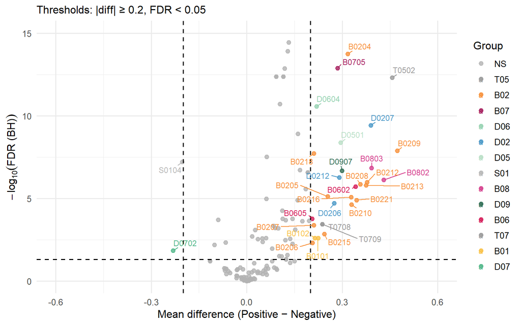

```r
fc_threshold <- 0.2      # minimum absolute mean difference to call interesting
fdr_threshold <- 0.05    # BH-adjusted p-value cutoff

functional_differences_devil_logfold <- functional_differences_devil %>%
  mutate(func = substr(GIFT, 1, 3)) %>%
  mutate(
    # guard against p_adj = 0 or NA
    p_adj_plot = ifelse(is.na(p_adj) | p_adj == 0, .Machine$double.xmin, p_adj),
    neglog10_fdr = -log10(p_adj_plot),
    hit = !is.na(p_adj) & p_adj < fdr_threshold & abs(diff) >= fc_threshold
  ) %>%
  mutate(func = ifelse(hit, func, "NS")) %>%
  filter(neglog10_fdr<20)

palette_df <- functional_differences_devil_logfold %>%
  dplyr::distinct(func) %>%
  dplyr::left_join(
    gift_colors %>% dplyr::select(func = Code_function, Color),
    by = "func"
  ) %>%
  dplyr::mutate(
    Color = dplyr::case_when(
      func == "NS" & is.na(Color) ~ "grey70",
      is.na(Color)                ~ "#999999",
      TRUE                        ~ Color
    )
  )

color_values <- setNames(palette_df$Color, palette_df$func)

functional_differences_devil_logfold %>%
  ggplot(aes(x = diff, y = neglog10_fdr, color=func)) +
  geom_point(aes(color = func), alpha = 0.8, size = 2) +
  geom_vline(xintercept = c(-fc_threshold, fc_threshold), linetype = "dashed") +
  geom_hline(yintercept = -log10(fdr_threshold), linetype = "dashed") +
  ylim(0,15)+
  xlim(-0.6,0.6)+
  ggrepel::geom_text_repel(
    data = subset(functional_differences_devil_logfold, hit),
    aes(label = GIFT),
    size = 3, max.overlaps = 20, box.padding = 0.3, min.segment.length = 0
  ) +
  scale_color_manual(values = color_values, breaks = names(color_values)) +
  labs(
    x = "Mean difference (Positive − Negative)",
    y = expression(-log[10]("FDR (BH)")),
    color = "Group",
    subtitle = paste0("Thresholds: |diff| ≥ ", fc_threshold, ", FDR < ", fdr_threshold)
  ) +
  theme_minimal(base_size = 12)
```

**Note:** Aggregate devil β coefficients to the functional group level by calculating mean β across all genomes carrying each functional trait. Identify the top 15 functional groups with strongest positive and negative associations, then create a forest plot showing functional group-level associations with credible intervals, colored by functional group.

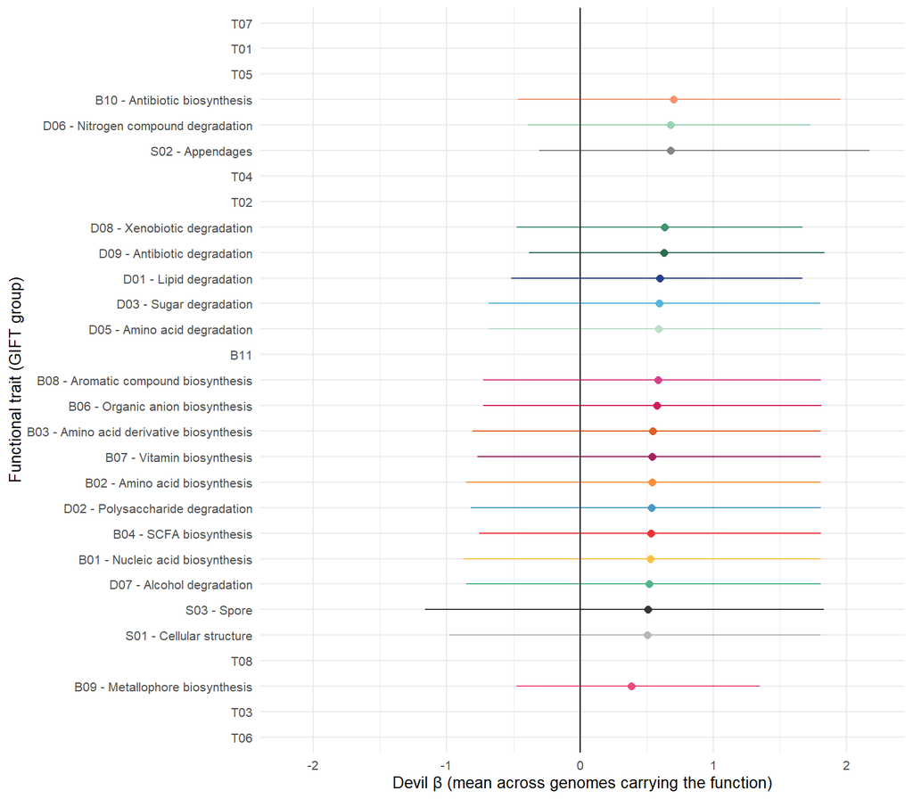

```r
# Map genomes to functional groups (GIFT 3-letter "func" code)
genome_func <- elements_response %>%
  dplyr::filter(value > 0) %>%
  dplyr::mutate(func = substr(GIFT, 1, 3)) %>%
  dplyr::distinct(genome, func)

# Summarise devil β across genomes for each functional group
devil_func_summary <- genome_func %>%
  dplyr::left_join(devil_ci %>% dplyr::select(genome, mean, q10, q90), by = "genome") %>%
  dplyr::group_by(func) %>%
  dplyr::summarise(
    n_genomes = sum(!is.na(mean)),
    mean_beta = mean(mean, na.rm = TRUE),
    q10_fun   = stats::quantile(mean, 0.10, na.rm = TRUE),
    q90_fun   = stats::quantile(mean, 0.90, na.rm = TRUE),
    .groups   = "drop"
  ) %>%
  dplyr::filter(n_genomes >= 3)

# Take top 15 positive & top 15 negative functions
N_top <- 15

devil_func_top <- dplyr::bind_rows(
  devil_func_summary %>%
    dplyr::slice_max(order_by = mean_beta, n = N_top, with_ties = FALSE),
  devil_func_summary %>%
    dplyr::slice_min(order_by = mean_beta, n = N_top, with_ties = FALSE)
) %>%
  dplyr::distinct(func, .keep_all = TRUE)

# Add nice labels & colours from gift_colors
devil_func_top <- devil_func_top %>%
  dplyr::left_join(
    gift_colors %>%
      dplyr::transmute(
        func        = Code_function,
        func_label  = legend,
        color       = Color
      ),
    by = "func"
  ) %>%
  dplyr::mutate(
    func_label = ifelse(is.na(func_label), func, func_label)
  )

func_cols <- setNames(devil_func_top$color, devil_func_top$func_label)

# Forest plot: functions instead of genomes
ggplot(
  devil_func_top,
  aes(x = mean_beta,
      y = forcats::fct_reorder(func_label, mean_beta),
      xmin = q10_fun, xmax = q90_fun,
      colour = func_label)
) +
  geom_point(size = 2) +
  geom_errorbar(width = 0) +
  geom_vline(xintercept = 0) +
  scale_color_manual(values = func_cols, guide = "none") +
  theme_minimal(base_size = 10) +
  labs(
    x = "Devil β (mean across genomes carrying the function)",
    y = "Functional trait (GIFT group)"
  )
```

## 15.3 Association with temperature

**Note:** Summarize temperature associations across taxonomic levels. Count and calculate percentages of genomes with positive and negative temperature associations at phylum, order, family, and genus levels. This helps identify which taxonomic groups show the strongest associations with temperature.

```r
post_table$temperature %>% table()
```

```
## .
## Positive  Neutral Negative
##      121      382       73
```

```r
temp_phylum_perc <- post_table %>%
  rownames_to_column(var = "genome") %>%
  left_join(genome_metadata, by = "genome") %>%
  group_by(phylum) %>%
  summarise(positive = sum(temperature == "Positive"),
            percent_positive = mean(temperature == "Positive") * 100,
            negative = sum(temperature == "Negative"),
            percent_negative = mean(temperature == "Negative") * 100)

temp_phylum_perc %>%
  arrange(-percent_positive)
```

```
## # A tibble: 13 × 5
##    phylum               positive percent_positive negative percent_negative
##    <chr>                   <int>            <dbl>    <int>            <dbl>
##  1 p__Actinomycetota           3           100           0              0
##  2 p__Desulfobacterota         2           100           0              0
##  3 p__Pseudomonadota           5            35.7         0              0
##  4 p__Bacteroidota             3            30           0              0
##  5 p__Bacillota_A            102            22.3        55             12.0
##  6 p__Synergistota             1            16.7         3             50
##  7 p__Bacillota                4            13.8         3             10.3
##  8 p__Cyanobacteriota          1             2.22        6             13.3
##  9 p__Bacillota_B              0             0           0              0
## 10 p__Bacillota_C              0             0           0              0
## 11 p__Campylobacterota         0             0           0              0
## 12 p__Thermoplasmatota         0             0           6            100
## 13 p__Verrucomicrobiota        0             0           0              0
```

```r
temp_phylum_perc %>%
  arrange(-percent_negative)
```

```
## # A tibble: 13 × 5
##    phylum               positive percent_positive negative percent_negative
##    <chr>                   <int>            <dbl>    <int>            <dbl>
##  1 p__Thermoplasmatota         0             0           6            100
##  2 p__Synergistota             1            16.7         3             50
##  3 p__Cyanobacteriota          1             2.22        6             13.3
##  4 p__Bacillota_A            102            22.3        55             12.0
##  5 p__Bacillota                4            13.8         3             10.3
##  6 p__Actinomycetota           3           100           0              0
##  7 p__Bacillota_B              0             0           0              0
##  8 p__Bacillota_C              0             0           0              0
##  9 p__Bacteroidota             3            30           0              0
## 10 p__Campylobacterota         0             0           0              0
## 11 p__Desulfobacterota         2           100           0              0
## 12 p__Pseudomonadota           5            35.7         0              0
## 13 p__Verrucomicrobiota        0             0           0              0
```

```r
# Sub-phylum level

post_table %>%
  rownames_to_column(var = "genome") %>%
  left_join(genome_metadata, by = "genome") %>%
  filter(phylum=="p__Bacillota_A") %>%
  group_by(order) %>%
  summarise(positive = sum(temperature == "Positive"),
            percent_positive = mean(temperature == "Positive") * 100,
            negative = sum(temperature == "Negative"),
            percent_negative = mean(temperature == "Negative") * 100) %>%
  arrange(-percent_positive)
```

```
## # A tibble: 8 × 5
##   order                   positive percent_positive negative percent_negative
##   <chr>                      <int>            <dbl>    <int>            <dbl>
## 1 o__Lachnospirales             70            38.0        21             11.4
## 2 o__Monoglobales                1            33.3         0              0
## 3 o__Oscillospirales            26            20.8        14             11.2
## 4 o__UBA1381                     1            10           0              0
## 5 o__TANB77                      3             6.38        6             12.8
## 6 o__Christensenellales          1             1.23       14             17.3
## 7 o__Peptostreptococcales        0             0           0              0
## 8 o__UMGS1883                    0             0           0              0
```

```r
post_table %>%
  rownames_to_column(var = "genome") %>%
  left_join(genome_metadata, by = "genome") %>%
  filter(order=="o__TANB77") %>%
  group_by(family) %>%
  summarise(positive = sum(temperature == "Positive"),
            percent_positive = mean(temperature == "Positive") * 100,
            negative = sum(temperature == "Negative"),
            percent_negative = mean(temperature == "Negative") * 100) %>%
  arrange(-percent_positive)
```

```
## # A tibble: 2 × 5
##   family     positive percent_positive negative percent_negative
##   <chr>         <int>            <dbl>    <int>            <dbl>
## 1 f__CAG-508        3             7.32        2             4.88
## 2 f__CAG-465        0             0           4            66.7
```

```r
post_table %>%
  rownames_to_column(var = "genome") %>%
  left_join(genome_metadata, by = "genome") %>%
  filter(family=="f__CAG-508") %>%
  group_by(genus) %>%
  summarise(positive = sum(temperature == "Positive"),
            percent_positive = mean(temperature == "Positive") * 100,
            negative = sum(temperature == "Negative"),
            percent_negative = mean(temperature == "Negative") * 100) %>%
  arrange(-percent_positive)
```

```
## # A tibble: 9 × 5
##   genus          positive percent_positive negative percent_negative
##   <chr>             <int>            <dbl>    <int>            <dbl>
## 1 g__JAAWPK01           1            33.3         0              0
## 2 g__CAG-269            1             8.33        0              0
## 3 g__Scatovivens        1             7.14        2             14.3
## 4 g__                   0             0           0              0
## 5 g__CAG-273            0             0           0              0
## 6 g__CAG-492            0             0           0              0
## 7 g__CAG-793            0             0           0              0
## 8 g__CAKPSH01           0             0           0              0
## 9 g__UMGS1994           0             0           0              0
```

**Note:** Extract posterior mean and support values for the temperature coefficient (β) for each genome. Create a scatter plot showing the relationship between the mean β coefficient and posterior support, colored by phylum. This visualization helps identify genomes with strong, well-supported associations with temperature.

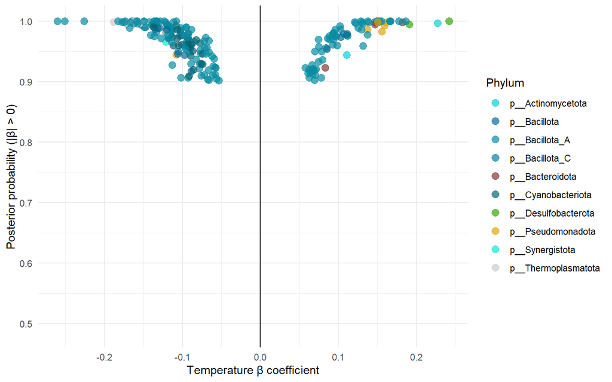

```r
temp_estimate <- getPostEstimate(hM = fit_model_16, parName = "Beta")$mean %>%
  as.data.frame() %>%
  mutate(variable = m$covNames) %>%
  filter(variable == "temperature") %>%
  pivot_longer(!variable, names_to = "genome", values_to = "mean") %>%
  dplyr::select(genome, mean)

temp_support <- getPostEstimate(hM = fit_model_16, parName = "Beta")$support %>%
  as.data.frame() %>%
  mutate(variable = m$covNames) %>%
  filter(variable == "temperature") %>%
  pivot_longer(!variable, names_to = "genome", values_to = "support") %>%
  dplyr::select(genome, support)

temp_beta <- inner_join(temp_estimate, temp_support, by = "genome") %>%
  left_join(genome_metadata, by = "genome")

temp_beta %>%
  mutate(significant = support >= support_threshold | support <= negsupport_threshold,
         support_plot = ifelse(mean < 0, 1 - support, support),
         phylum_sig = ifelse(significant & support_plot > 0.9, phylum, NA)) %>%
  ggplot(aes(x = mean, y = support_plot, colour = phylum_sig)) +
  geom_point(alpha = 0.7, size = 3) +
  scale_color_manual(values = phylum_colors, na.translate = FALSE) +
  geom_vline(xintercept = 0) +
  labs(x = "Temperature β coefficient",
       y = "Posterior probability (|β| > 0)",
       colour = "Phylum") +
  theme_minimal()
```

**Note:** Calculate 80% credible intervals (10th and 90th percentiles) for the temperature β coefficient for each genome. Filter to genomes with credible non-zero effects (where the credible interval does not include zero) and visualize these with error bars, ordered by mean β value.

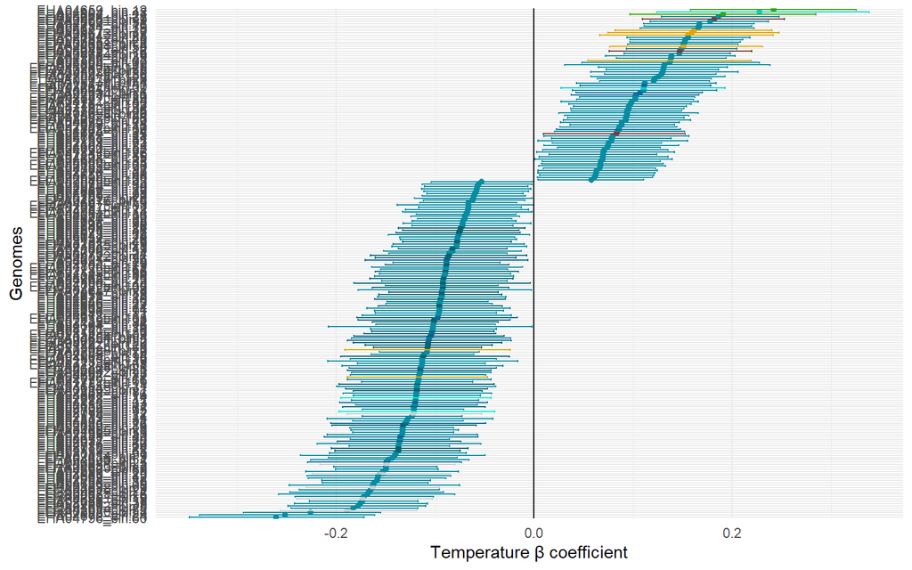

```r
temp_q <- getPostEstimate(hM = fit_model_16,
                          parName = "Beta",
                          q = c(0.1, 0.9))$q
idx_temp <- which(m$covNames == "temperature")
n_genomes <- length(m$spNames)

temp_ci <- map_dfr(1:n_genomes, ~ {
  tibble(
    genome = m$spNames[.x],
    q10 = temp_q[1, idx_temp, .x],
    q90 = temp_q[2, idx_temp, .x]
  )
}) %>%
  right_join(temp_estimate, by = "genome") %>%
  left_join(genome_metadata, by = "genome")

temp_ci %>%
  filter(q10 > 0 | q90 < 0) %>%
  ggplot(aes(x = mean,
             y = forcats::fct_reorder(genome, mean),
             xmin = q10, xmax = q90,
             colour = phylum)) +
  geom_point() +
  geom_errorbar() +
  geom_vline(xintercept = 0) +
  scale_color_manual(values = phylum_colors) +
  theme_minimal() +
  labs(x = "Temperature β coefficient",
       y = "Genomes") +
  theme(legend.position = "none")
```

**Note:** Identify and visualize the top 30 genomes with the strongest positive and top 30 with the strongest negative credible temperature associations. Create a forest plot showing these top genomes with their credible intervals, faceted by association direction (positive/negative), ordered by mean β coefficient and colored by phylum.

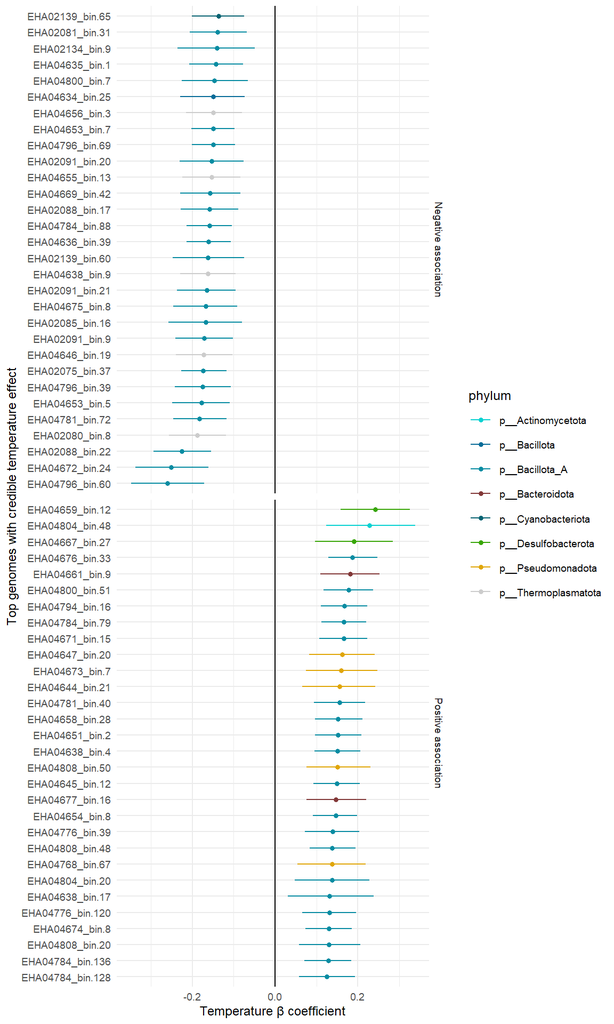

```r
# --- Temperature credible intervals: top 30 genomes ---

# Keep only genomes with credible non-zero temperature effect
temp_ci_sig <- temp_ci %>%
  dplyr::filter(q10 > 0 | q90 < 0)

# 4. Take top 30 positive and top 30 negative genomes
N_top <- 30

temp_ci_top <- temp_ci_sig %>%
  dplyr::slice_max(order_by = mean, n = N_top, with_ties = FALSE) %>%
  dplyr::bind_rows(
    temp_ci_sig %>%
      dplyr::slice_min(order_by = mean, n = N_top, with_ties = FALSE)
  ) %>%
  dplyr::distinct(genome, .keep_all = TRUE) %>%
  dplyr::mutate(
    direction = ifelse(mean > 0, "Positive association", "Negative association"),
    genome    = forcats::fct_reorder(genome, mean)
  )

# 5. Plot credible intervals for these top genomes
temp_ci_top %>%
  ggplot2::ggplot(ggplot2::aes(x = mean,
                               y = genome,
                               xmin = q10, xmax = q90,
                               colour = phylum)) +
  ggplot2::geom_point() +
  ggplot2::geom_errorbar(width = 0) +
  ggplot2::geom_vline(xintercept = 0) +
  ggplot2::scale_color_manual(values = phylum_colors) +
  ggplot2::facet_grid(direction ~ ., scales = "free_y", space = "free_y") +
  ggplot2::theme_minimal(base_size = 9) +
  ggplot2::labs(
    x = "Temperature β coefficient",
    y = "Top genomes with credible temperature effect"
  ) +
  ggplot2::theme(legend.position = "right")
```

### 15.3.1 2) Temperature – phylum-level summary of β

**Note:** Summarize temperature β coefficients at the phylum level by calculating mean β and 80% credible intervals (10th and 90th percentiles) for each phylum. Visualize phylum-level associations with error bars to show the overall pattern of temperature associations across major taxonomic groups.

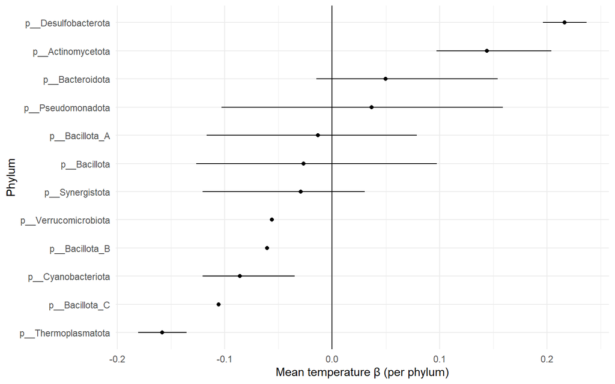

```r
temp_phylum_ci <- temp_ci %>%
  dplyr::group_by(phylum) %>%
  dplyr::summarise(
    mean_beta = mean(mean, na.rm = TRUE),
    q10       = stats::quantile(mean, 0.1, na.rm = TRUE),
    q90       = stats::quantile(mean, 0.9, na.rm = TRUE),
    .groups   = "drop"
  )

temp_phylum_ci %>%
  ggplot2::ggplot(ggplot2::aes(x = mean_beta,
                               y = forcats::fct_reorder(phylum, mean_beta),
                               xmin = q10, xmax = q90)) +
  ggplot2::geom_point() +
  ggplot2::geom_errorbar(width = 0) +
  ggplot2::geom_vline(xintercept = 0) +
  ggplot2::theme_minimal() +
  ggplot2::labs(
    x = "Mean temperature β (per phylum)",
    y = "Phylum"
  )
```

**Note:** Compare functional element (GIFT) abundances between genomes with positive versus negative temperature associations. For each functional element, calculate mean abundances in each group, compute differences, and perform t-tests. Adjust p-values using Benjamini-Hochberg FDR correction to identify functional elements that differ significantly between temperature-associated groups.

```r
functional_differences_temperature <- elements_response %>%
  filter(temperature !="Neutral") %>%
  mutate(temperature = droplevels(temperature)) %>%
  group_by(GIFT) %>%
  summarise(
    n_pos   = sum(temperature == "Positive"),
    n_neg   = sum(temperature == "Negative"),
    mean_pos = mean(value[temperature == "Positive"], na.rm = TRUE),
    mean_neg = mean(value[temperature == "Negative"], na.rm = TRUE),
    diff     = mean_pos - mean_neg,
    p        = if (n_pos > 1 && n_neg > 1 &&
                   stats::sd(value[temperature == "Positive"], na.rm = TRUE) > 0 &&
                   stats::sd(value[temperature == "Negative"], na.rm = TRUE) > 0) {
                stats::t.test(value ~ temperature, var.equal = FALSE)$p.value
              } else NA_real_
  , .groups = "drop") %>%
  mutate(p_adj = p.adjust(p, method = "BH")) %>%
  arrange(p_adj)
```

**Note:** Create a volcano plot visualizing functional differences between positive and negative temperature-associated genomes. Plot mean difference (fold change) against -log10(FDR), with functional elements colored by their functional group. Highlight significant elements that meet both fold change and FDR thresholds, with labels for the most significant hits.

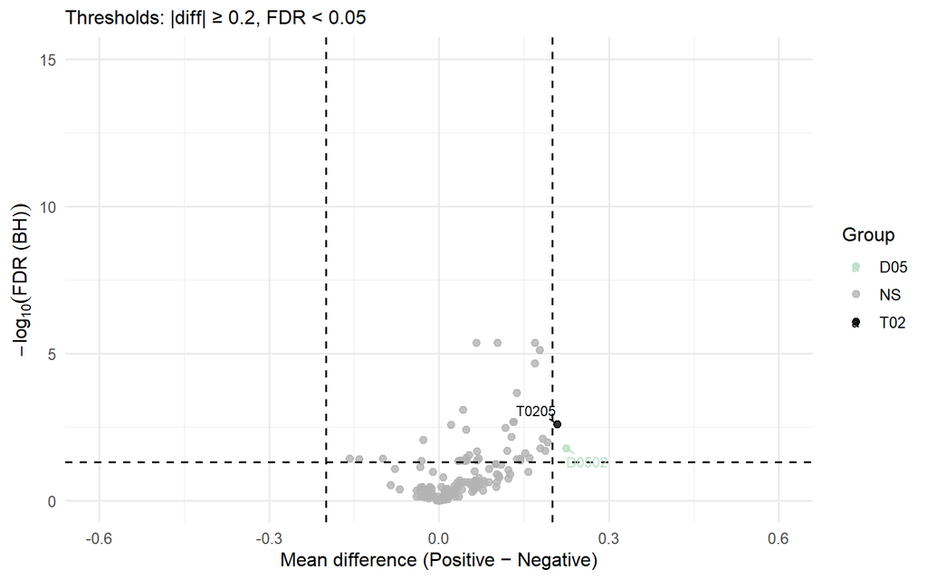

```r
fc_threshold <- 0.2      # minimum absolute mean difference to call interesting
fdr_threshold <- 0.05    # BH-adjusted p-value cutoff

functional_differences_temperature_logfold <- functional_differences_temperature %>%
  mutate(func = substr(GIFT, 1, 3)) %>%
  mutate(
    # guard against p_adj = 0 or NA
    p_adj_plot   = ifelse(is.na(p_adj) | p_adj == 0, .Machine$double.xmin, p_adj),
    neglog10_fdr = -log10(p_adj_plot),
    hit          = !is.na(p_adj) & p_adj < fdr_threshold & abs(diff) >= fc_threshold
  ) %>%
  mutate(func = ifelse(hit, func, "NS")) %>%   # NS = non-significant / background
  filter(neglog10_fdr < 20)

# ---- Build a safe colour vector for all func levels ----
func_levels <- sort(unique(functional_differences_temperature_logfold$func))

palette_df <- tibble::tibble(func = func_levels) %>%
  dplyr::left_join(
    gift_colors %>%
      dplyr::select(func = Code_function, Color),
    by = "func"
  ) %>%
  dplyr::mutate(
    Color = dplyr::case_when(
      func == "NS" & is.na(Color) ~ "grey70",   # neutral colour for NS
      is.na(Color)                ~ "black",    # fallback for any unknown func
      TRUE                        ~ Color
    )
  )

color_values <- setNames(palette_df$Color, palette_df$func)

functional_differences_temperature_logfold %>%
  ggplot(aes(x = diff, y = neglog10_fdr, color = func)) +
  geom_point(alpha = 0.8, size = 2) +
  geom_vline(xintercept = c(-fc_threshold, fc_threshold), linetype = "dashed") +
  geom_hline(yintercept = -log10(fdr_threshold), linetype = "dashed") +
  ylim(0, 15) +
  xlim(-0.6, 0.6) +
  ggrepel::geom_text_repel(
    data = subset(functional_differences_temperature_logfold, hit),
    aes(label = GIFT),
    size = 3, max.overlaps = 20, box.padding = 0.3, min.segment.length = 0
  ) +
  scale_color_manual(values = color_values) +
  labs(
    x = "Mean difference (Positive − Negative)",
    y = expression(-log[10]("FDR (BH)")),
    color = "Group",
    subtitle = paste0(
      "Thresholds: |diff| ≥ ", fc_threshold,
      ", FDR < ", fdr_threshold
    )
  ) +
  theme_minimal(base_size = 12)
```

**Note:** Aggregate temperature β coefficients to the functional group level by calculating mean β across all genomes carrying each functional trait. Identify the top 15 functional groups with strongest positive and negative associations, then create a forest plot showing functional group-level associations with credible intervals, colored by functional group.

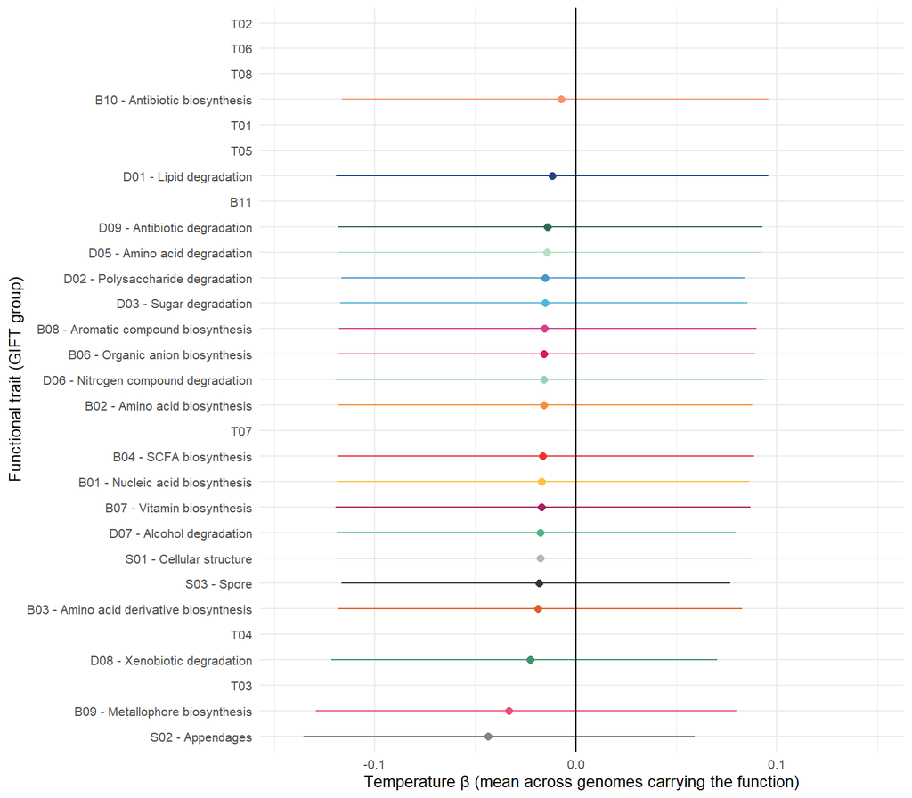

```r
# Map genomes to functional groups (GIFT 3-letter codes)
genome_func_temp <- elements_response %>%
  dplyr::filter(value > 0) %>%
  dplyr::mutate(func = substr(GIFT, 1, 3)) %>%
  dplyr::distinct(genome, func)

# Summarise temperature β across genomes for each functional group
temp_func_summary <- genome_func_temp %>%
  dplyr::left_join(temp_ci %>% dplyr::select(genome, mean, q10, q90), by = "genome") %>%
  dplyr::group_by(func) %>%
  dplyr::summarise(
    n_genomes = sum(!is.na(mean)),
    mean_beta = mean(mean, na.rm = TRUE),
    q10_fun   = stats::quantile(mean, 0.10, na.rm = TRUE),
    q90_fun   = stats::quantile(mean, 0.90, na.rm = TRUE),
    .groups   = "drop"
  ) %>%
  dplyr::filter(n_genomes >= 3)

# Take top 15 positive & top 15 negative functions
N_top <- 15

temp_func_top <- dplyr::bind_rows(
  temp_func_summary %>%
    dplyr::slice_max(order_by = mean_beta, n = N_top, with_ties = FALSE),
  temp_func_summary %>%
    dplyr::slice_min(order_by = mean_beta, n = N_top, with_ties = FALSE)
) %>%
  dplyr::distinct(func, .keep_all = TRUE)

# Add nice labels & colours from gift_colors
temp_func_top <- temp_func_top %>%
  dplyr::left_join(
    gift_colors %>%
      dplyr::transmute(
        func        = Code_function,
        func_label  = legend,
        color       = Color
      ),
    by = "func"
  ) %>%
  dplyr::mutate(
    func_label = ifelse(is.na(func_label), func, func_label)
  )

func_cols_temp <- setNames(temp_func_top$color, temp_func_top$func_label)

# Forest plot: functional groups for temperature

ggplot(
  temp_func_top,
  aes(x = mean_beta,
      y = forcats::fct_reorder(func_label, mean_beta),
      xmin = q10_fun, xmax = q90_fun,
      colour = func_label)
) +
  geom_point(size = 2) +
  geom_errorbar(width = 0) +
  geom_vline(xintercept = 0) +
  scale_color_manual(values = func_cols_temp, guide = "none") +
  theme_minimal(base_size = 10) +
  labs(
    x = "Temperature β (mean across genomes carrying the function)",
    y = "Functional trait (GIFT group)"
  )
```